# Test a Perceptual Phenomenon

### Analyzing the Stroop Effect

```python
#import pandas
import pandas as pd

df = pd.read_csv('stroopdata.csv')
df.head()
```

|  | Congruent | Incongruent |
| --- | --- | --- |
| 0 | 12.079 | 19.278 |
| 1 | 16.791 | 18.741 |
| 2 | 9.564 | 21.214 |
| 3 | 8.630 | 15.687 |
| 4 | 14.669 | 22.803 |

(1) What is the independent variable? What is the dependent variable?

> For this project, the independent variables are the conditions in which the words are printed - the type of test. That is, congruent and incongruent conditions.

> The dependent variable is time -- the amount of time it takes to name a color.

(2) What is an appropriate set of hypotheses for this task? Specify your null and alternative hypotheses, and clearly define any notation used. Justify your choices.

Hypothesis $$H_o: \mu_c = \mu_i $$ $$H_1: \mu_c \neq \mu_i $$

Where,

$\mu_c$: Population response mean time for congruent test.

$\mu_i$: Population response mean time for incongruent test.

$H_o$: There is no significant difference between the congruent test response mean time and incongruent test response mean time.

$H_1$: There is significant difference between the congruent test response mean time and incongruent test response mean time.

For this analysis, we will be using a student t-test (for paired samples) since the sample size n is less than 30 and drawn at different times.

(3) Report some descriptive statistics regarding this dataset. Include at least one measure of central tendency and at least one measure of variability. The name of the data file is 'stroopdata.csv'.

```python
# descriptive stats

df.describe()
```

|  | Congruent | Incongruent |
| --- | --- | --- |
| count | 24.000000 | 24.000000 |
| mean | 14.051125 | 22.015917 |
| std | 3.559358 | 4.797057 |
| min | 8.630000 | 15.687000 |
| 25% | 11.895250 | 18.716750 |
| 50% | 14.356500 | 21.017500 |
| 75% | 16.200750 | 24.051500 |
| max | 22.328000 | 35.255000 |

> On average the mean response time for the Congruent test is 14.05 seconds with a standard deviation of 3.56. For the congruent test, it took 50% of the respondents approximately 14 seconds to respond.

> On average the mean response time for the incongruent test is 22.01 seconds with a standard deviation of 4.80. For the incongruent test, it took 50% of the respondents approximately 21 seconds to respond.

(4) Provide one or two visualizations that show the distribution of the sample data. Write one or two sentences noting what you observe about the plot or plots.

```python
import seaborn as sns
import matplotlib.pyplot as plt
%matplotlib inline
```

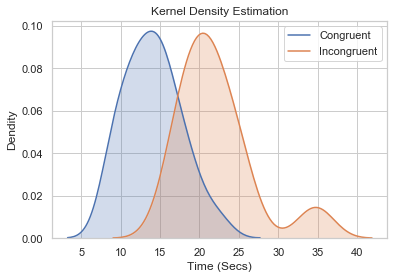

```python
sns.kdeplot(df.Congruent, shade=True)
sns.kdeplot(df.Incongruent, shade=True)
plt.xlabel('Time (Secs)')
plt.ylabel('Dendity')
plt.title('Kernel Density Estimation');
```

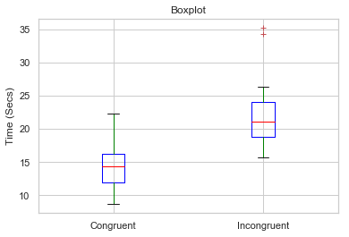

```python
color = dict(boxes='Blue', whiskers='Green', medians='red')
df.plot.box(sym = 'r+', color=color, style="whitegrid")
plt.ylabel('Time (Secs)')
plt.title('Boxplot');
```

> It is observed that the response time for both congruent and incongruent test seem to be normally distributed with small variances. There however seem to be a little spike towards the right tail. The boxplot points this little spike as an outlier.

(5) Now, perform the statistical test and report your results. What is your confidence level or Type I error associated with your test? What is your conclusion regarding the hypotheses you set up? Did the results match up with your expectations? **Hint:** Think about what is being measured on each individual, and what statistic best captures how an individual reacts in each environment.

```python
import scipy.stats as stats
t_value, p_value = stats.ttest_rel(df.Congruent, df.Incongruent)
t_value, p_value
```

```
(-8.020706944109957, 4.103000585711178e-08)
```

> The above test is conducted at 5% level of significance.

> Since the p_value, 4.103000585711178e-08, is less than 0.05, we reject the null hypothesis and conclude that there is significant difference between the mean response times, $\mu_c$ and $\mu_i$.

> Not surprisingly, the results did match up with my expectation.

(6) Optional: What do you think is responsible for the effects observed? Can you think of an alternative or similar task that would result in a similar effect? Some research about the problem will be helpful for thinking about these two questions!

The response observed is a result of what could be termed as **learned response**. Humans are used to reading the meaning of words while ignoring their physical features. So, when there's a conflict between a written word and its feature (in this case, color), we are compelled to focus on the feature rather than the meaning. This turns out to be quite tasking, as we have to learn how to respond differently. Of course, this results to slow response/reaction because "naming the actual color of the words requires much more attention than simply reading the text" and "people can read words much faster than they can name colors."

1. [What is the Stroop Effect](https://www.verywellmind.com/what-is-the-stroop-effect-2795832)
2. [Stroop Effect](https://www.psytoolkit.org/lessons/stroop.html)